# Final Project

Jacob Lyman

April 1, 2019

[figure not shown]

# **The Project Underway**

Recommending the right questions for a programmer to solve is a big challenge for online education platforms. Nevertheless, this is essential to keep users engaged.

Recommended questions should be ones that are within the skill level of a respective user. The question that this project will address is “For a given programmer, how much time will they take to solve a given problem?” To answer this question, I will build a model to make such predictions based on a programmer’s historical platform interactions, their background, and the characteristics of a given problem.

Knowing the expected time for a solution will provide insight as to which level of questions should be recommended to a user. The product of this project will serve as the basis for a recommendation engine, which will address a broader question of “What question(s) should be recommended to a programmer to keep them engaged?”

## “Why *this* project?”

I’ve chosen this project because it directly relates to some of the work that I hope to do for Pluralsight. My position within the company is a Business Analyst on the Experience Strategy & Operations team. Part of my responsibilities will be to quantitatively support the decisions that the team makes to drive better user experiences on their platform. Since their users are typically programmers, I felt that this project would be great practice.

# **Exploratory Data Analysis**

For this project we have access to three data tables: Historical Data (`historyData`), Problem Data (`problemData`), and User Data (`userData`).

Historical Data dimensions:

```
## [1] 155295      3
```

Problem Data dimensions:

```
## [1] 6544    4
```

User Data dimensions:

```
## [1] 3571   11
```

We’ll take an indepth look at each data table separately.

## Historical Data

```
## Classes 'data.table' and 'data.frame':   155295 obs. of  3 variables:
##  $ user_id       : chr  "user_232" "user_3568" "user_1600" "user_2256" ...
##  $ problem_id    : chr  "prob_6507" "prob_2994" "prob_5071" "prob_703" ...
##  $ attempts_range: int  1 3 1 1 1 1 1 2 1 1 ...
##  - attr(*, ".internal.selfref")=<externalptr>
```

| user_id | problem_id | attempts_range |
| --- | --- | --- |
| user_232 | prob_6507 | 1 |
| user_3568 | prob_2994 | 3 |
| user_1600 | prob_5071 | 1 |
| user_2256 | prob_703 | 1 |
| user_2321 | prob_356 | 1 |
| user_1569 | prob_6064 | 1 |
| user_3293 | prob_1237 | 1 |
| user_915 | prob_4125 | 2 |
| user_2032 | prob_1943 | 1 |
| user_1410 | prob_3935 | 1 |
| user_2085 | prob_5436 | 1 |
| user_1810 | prob_3431 | 2 |
| user_1287 | prob_3474 | 1 |
| user_2063 | prob_2872 | 1 |
| user_724 | prob_6043 | 2 |
| user_88 | prob_1914 | 2 |
| user_2269 | prob_5641 | 1 |
| user_489 | prob_522 | 1 |
| user_1997 | prob_32 | 1 |
| user_1929 | prob_5731 | 2 |
| user_2084 | prob_4232 | 1 |
| user_923 | prob_3508 | 2 |
| user_150 | prob_6488 | 1 |
| user_2898 | prob_1605 | 1 |
| user_3086 | prob_2605 | 1 |
| user_2552 | prob_534 | 1 |
| user_508 | prob_3073 | 1 |
| user_1910 | prob_6442 | 4 |
| user_1066 | prob_106 | 1 |
| user_1637 | prob_1482 | 1 |
| user_2561 | prob_164 | 2 |
| user_812 | prob_5804 | 1 |
| user_2340 | prob_6426 | 2 |
| user_1912 | prob_1149 | 3 |
| user_3185 | prob_1346 | 1 |
| user_1102 | prob_1047 | 1 |
| user_1150 | prob_3038 | 1 |
| user_771 | prob_5954 | 3 |
| user_1155 | prob_6321 | 1 |
| user_3221 | prob_1084 | 2 |
| user_2307 | prob_2811 | 1 |
| user_2906 | prob_620 | 4 |
| user_1828 | prob_4076 | 1 |
| user_194 | prob_6266 | 1 |
| user_3155 | prob_1095 | 1 |
| user_3568 | prob_4278 | 1 |
| user_2953 | prob_4407 | 1 |
| user_807 | prob_4053 | 2 |
| user_661 | prob_583 | 1 |
| user_1964 | prob_1481 | 1 |

*NOTE: This table only includes the first 50 observations.

The `historyData` is our largest data table. It includes 155,295 observations of brief interactive data between various programmers and online problems, specifically recording the total attempts (`attempst_range`) that a given programmer took to solve a respective problem.

The primary variable of interest, and our upcoming dependent variable for our predictions, is `attempts_range`.

| attempts_range | # of attempts | count |
| --- | --- | --- |
| 1 | 1-1 | 82804 |
| 2 | 2-3 | 47320 |
| 3 | 4-5 | 14143 |
| 4 | 6-7 | 5499 |
| 5 | 8-9 | 2496 |
| 6 | >=10 | 3033 |

Each level within `attempts_range` represents a bin for the number of attempts that a programmer took to solve a given problem in `historyData`. Later in this project, I will train a model to predict the expected `attempts_range`, between 1-6, for a given programmer to solve a given problem based on its charactersistics and the programmer’s respective background.

How many unique programmers do we have in `historyData`?

```r
length(unique(historyData$user_id))
```

```
## [1] 3529
```

Interestingly enough, not all of the users within `userData` show up in the `historyData`. We have the background information for an additional 42 programmers to be exact. Nevertheless, this will not cause any issues within the scope of this project.

How many times does each unique user show up in `historyData`?

| user | count |
| --- | --- |
| user_1 | 60 |
| user_10 | 51 |
| user_100 | 57 |
| user_1000 | 55 |
| user_1001 | 58 |
| user_1002 | 39 |
| user_1003 | 11 |
| user_1004 | 48 |
| user_1005 | 50 |
| user_1006 | 2 |
| user_1007 | 5 |
| user_1008 | 72 |
| user_1009 | 105 |
| user_101 | 5 |
| user_1010 | 60 |
| user_1011 | 53 |
| user_1012 | 31 |
| user_1013 | 29 |
| user_1014 | 29 |
| user_1015 | 47 |
| user_1016 | 8 |
| user_1017 | 89 |
| user_1018 | 46 |
| user_1019 | 70 |
| user_102 | 1 |
| user_1020 | 41 |
| user_1021 | 1 |
| user_1022 | 61 |
| user_1023 | 72 |
| user_1024 | 73 |

[output cut: 70 more lines]

*NOTE: This table only includes the first 100 observations.

```
##    Min. 1st Qu.  Median    Mean 3rd Qu.    Max.
##    1.00   32.00   46.00   44.01   57.00  105.00
```

On average, a programmer will have answered 44 problems and can be expected to be found in `historyData` around 44 times.

How many unique problems do we have in `historyData`?

```r
length(unique(historyData$problem_id))
```

```
## [1] 5776
```

Similar to `userData`, the `historyData` doesn’t include all of the problems that are in the `problemData`. We have information for an additional 768 problems to be exact. Nevertheless, this also won’t cause any problems for the purposes of this project.

How many times does each unique problem show up in this table?

| problem | count |
| --- | --- |
| prob_1 | 2 |
| prob_10 | 1 |
| prob_100 | 1 |
| prob_1000 | 246 |
| prob_1001 | 10 |
| prob_1002 | 3 |
| prob_1003 | 6 |
| prob_1004 | 1 |
| prob_1005 | 84 |
| prob_1006 | 30 |
| prob_1007 | 6 |
| prob_1008 | 2 |
| prob_1009 | 2 |
| prob_101 | 23 |
| prob_1010 | 52 |
| prob_1011 | 9 |
| prob_1012 | 10 |
| prob_1013 | 1 |
| prob_1015 | 17 |
| prob_1016 | 1 |
| prob_1018 | 9 |
| prob_1019 | 79 |
| prob_102 | 24 |
| prob_1020 | 1 |
| prob_1021 | 6 |
| prob_1022 | 5 |
| prob_1023 | 7 |
| prob_1024 | 4 |
| prob_1025 | 2 |
| prob_1026 | 59 |

[output cut: 70 more lines]

*NOTE: This table only includes the first 100 observations.

```
##    Min. 1st Qu.  Median    Mean 3rd Qu.    Max.
##    1.00    2.00    5.00   26.89   17.00 1365.00
```

Looking at the above distribution, we can see that there is a large spread between the number of times a problem is answered by users. The most a problem was answered was 1,365 times. Perhaps this is one of the introductory problems of the online platform?

Lastly, let’s check to see if we have any NAs in `historyData`:

```r
dataNA <- apply(historyData, 1, function(x) sum(is.na(x)))
sum(dataNA)
```

```
## [1] 0
```

No, we do not.

## Problem Data

```
## Classes 'data.table' and 'data.frame':   6544 obs. of  4 variables:
##  $ problem_id: chr  "prob_3649" "prob_6191" "prob_2020" "prob_313" ...
##  $ level_type: chr  "H" "A" "F" "A" ...
##  $ points    : num  NA NA NA 500 500 NA NA 5 NA NA ...
##  $ tags      : chr  "" "" "" "greedy,implementation" ...
##  - attr(*, ".internal.selfref")=<externalptr>
```

| problem_id | level_type | points | tags |
| --- | --- | --- | --- |
| prob_3649 | H | NA |  |
| prob_6191 | A | NA |  |
| prob_2020 | F | NA |  |
| prob_313 | A | 500 | greedy,implementation |
| prob_101 | A | 500 | constructive algorithms,greedy,math |
| prob_1479 | E | NA |  |
| prob_2940 | B | NA |  |
| prob_3059 | B | 5 | brute force |
| prob_1958 | D | NA |  |
| prob_6154 | C | NA |  |
| prob_4069 | B | 1000 | dfs and similar,dsu,graphs |
| prob_4926 | A | 500 | implementation |
| prob_3154 | K | NA |  |
| prob_1538 | A | NA |  |
| prob_3750 | B | 1000 | math |
| prob_4440 | I | NA |  |
| prob_4569 | A | NA |  |
| prob_4189 | D | NA |  |
| prob_526 | D | 2000 | math,number theory |
| prob_5498 | I | NA |  |
| prob_3216 | F | NA |  |
| prob_1412 | C | 1500 | brute force,dp,number theory |
| prob_5088 | B | NA |  |
| prob_5693 | D | 2000 | brute force,dfs and similar,graphs |
| prob_75 | A | 500 | implementation |
| prob_1035 | I | NA |  |
| prob_2822 | C | NA | data structures,expression parsing,math |
| prob_3277 | D | 2000 | dfs and similar,greedy |
| prob_3284 |  | NA |  |
| prob_3714 | D | NA |  |

[output cut: 70 more lines]

*NOTE: This table only includes the first 100 observations.

The `problemData` includes a total of 6,544 different problems that can be given to a user. These problems vary in difficulty and genre.

By viewing the above table, we can already tell that we have some NAs within the `problemData`. How many are there?

```r
problemNA <- apply(problemData, 1, function(x) sum(is.na(x)))
sum(problemNA)
```

```
## [1] 3917
```

A lot. Which features contain NAs?

```r
columnNAs <- colnames(problemData)[colSums(is.na(problemData)) > 0]
columnNAs
```

```
## [1] "points"
```

It appears that the `points` feature is the only one that contains NAs. Naturally, `points` indicates the amount of points that a programmer can receive for solving a given problem. Though I don’t know what these points might apply to, we can assume that users have an incentive to collect points to meet some sort of goal. There are only two explanations for there to be missing data in this feature: (1) Some problems offer points while others do not or (2) the data is missing due to data collection limitations. At this time, I don’t know which of the two options is the most likely.

Additionally, we can see that there is missing data in two other features, namely the `level_type` and `tags` features. The `level_type` indicates the difficulty level of a given problem, while the `tags` feature indicates any particular facets of a problem.

| level | count |
| --- | --- |
|  | 133 |
| A | 1042 |
| B | 1017 |
| C | 915 |
| D | 850 |
| E | 795 |
| F | 421 |
| G | 328 |
| H | 272 |
| I | 256 |
| J | 212 |
| K | 154 |
| L | 99 |
| M | 40 |
| N | 10 |

While it’s reasonable to assume that problems without a tag are simply generic, I’m unsure why certain problems are not assigned a specific level. However, it’s obvious that there are fewer and fewer problems with each advancment in level. Perhaps the problems that currently do not have a `level_type` assigned are both the same level *and* belong in sequence with the other levels in the above table, ordered by count. The label for these problems might’ve been unintentionally ommitted.

How many unique `tags` do we have in `problemData`?

```r
length(unique(problemData$tags))
```

```
## [1] 883
```

| tags | count |
| --- | --- |
|  | 3484 |
| *special | 52 |
| *special,binary search | 1 |
| *special,binary search,sortings,two pointers | 1 |
| *special,brute force | 2 |
| *special,brute force,constructive algorithms,dsu,implementation | 1 |
| *special,brute force,implementation | 1 |
| *special,brute force,implementation,number theory | 1 |
| *special,brute force,number theory | 2 |
| *special,brute force,ternary search | 1 |
| *special,combinatorics | 1 |
| *special,constructive algorithms | 2 |
| *special,constructive algorithms,greedy | 1 |
| *special,constructive algorithms,sortings | 1 |
| *special,dp | 2 |
| *special,expression parsing | 1 |
| *special,expression parsing,implementation | 1 |
| *special,graph matchings,implementation,trees | 1 |
| *special,implementation | 19 |
| *special,implementation,strings | 2 |
| *special,math | 1 |
| *special,number theory | 1 |
| *special,sortings | 1 |
| 2-sat,binary search | 1 |
| 2-sat,brute force,graph matchings,greedy,implementation | 1 |
| 2-sat,dfs and similar,dsu,graph matchings,greedy | 1 |
| 2-sat,dfs and similar,dsu,graphs | 4 |
| 2-sat,greedy | 1 |
| binary search | 10 |
| binary search,bitmasks,brute force | 1 |

[output cut: 853 more lines]

That’s actually super helpful to know. There are 883 unique tag combinations. Along with this, we can see that 3,484 problems don’t have any tag whatsoever.

## User Data

```
## Classes 'data.table' and 'data.frame':   3571 obs. of  11 variables:
##  $ user_id                  : chr  "user_3311" "user_3028" "user_2268" "user_480" ...
##  $ submission_count         : int  47 63 226 611 504 3 216 2 91 91 ...
##  $ problem_solved           : int  40 52 203 490 479 1 199 1 79 71 ...
##  $ contribution             : int  0 0 -8 1 12 0 0 0 0 0 ...
##  $ country                  : chr  "" "India" "Egypt" "Ukraine" ...
##  $ follower_count           : int  4 17 24 94 4 0 28 0 0 4 ...
##  $ last_online_time_seconds : int  1504111645 1498998165 1505566052 1505257499 1496613433 1484244659 1505534677 1505568051 1502437836 1494953565 ...
##  $ max_rating               : num  348 406 307 526 549 ...
##  $ rating                   : num  331 339 284 471 487 ...
##  $ rank                     : chr  "intermediate" "intermediate" "beginner" "advanced" ...
##  $ registration_time_seconds: int  1466686436 1441893325 1454267603 1350720417 1395560498 1484233893 1443374825 1484233261 1472711718 1403610149 ...
##  - attr(*, ".internal.selfref")=<externalptr>
```

| user_id | submission_count | problem_solved | contribution | country | follower_count | last_online_time_seconds | max_rating | rating | rank | registration_time_seconds |
| --- | --- | --- | --- | --- | --- | --- | --- | --- | --- | --- |
| user_3311 | 47 | 40 | 0 |  | 4 | 1504111645 | 348.337 | 330.849 | intermediate | 1466686436 |
| user_3028 | 63 | 52 | 0 | India | 17 | 1498998165 | 405.677 | 339.450 | intermediate | 1441893325 |
| user_2268 | 226 | 203 | -8 | Egypt | 24 | 1505566052 | 307.339 | 284.404 | beginner | 1454267603 |
| user_480 | 611 | 490 | 1 | Ukraine | 94 | 1505257499 | 525.803 | 471.330 | advanced | 1350720417 |
| user_650 | 504 | 479 | 12 | Russia | 4 | 1496613433 | 548.739 | 486.525 | advanced | 1395560498 |
| user_3177 | 3 | 1 | 0 |  | 0 | 1484244659 | 331.135 | 331.135 | intermediate | 1484233893 |
| user_2032 | 216 | 199 | 0 | India | 28 | 1505534677 | 387.328 | 387.328 | intermediate | 1443374825 |
| user_3306 | 2 | 1 | 0 |  | 0 | 1505568051 | 304.186 | 281.250 | beginner | 1484233261 |
| user_1483 | 91 | 79 | 0 |  | 0 | 1502437836 | 318.807 | 258.888 | beginner | 1472711718 |
| user_667 | 91 | 71 | 0 |  | 4 | 1494953565 | 383.028 | 362.959 | intermediate | 1403610149 |
| user_2871 | 12 | 12 | 0 | China | 16 | 1494188847 | 484.805 | 484.805 | advanced | 1437614555 |
| user_972 | 473 | 441 | 0 | Indonesia | 88 | 1486246510 | 491.112 | 403.670 | intermediate | 1298904768 |
| user_1972 | 107 | 99 | 0 | India | 11 | 1504291325 | 304.186 | 203.842 | beginner | 1439050893 |
| user_3031 | 669 | 632 | 0 | Syria | 63 | 1505214481 | 356.938 | 303.899 | beginner | 1436078122 |
| user_2771 | 229 | 218 | 0 | Poland | 6 | 1505561151 | 375.000 | 355.218 | intermediate | 1449761313 |
| user_991 | 338 | 311 | 0 | Ukraine | 14 | 1505421713 | 361.525 | 341.743 | intermediate | 1478808471 |
| user_663 | 482 | 463 | -3 | India | 114 | 1505579161 | 452.408 | 418.291 | intermediate | 1463038622 |
| user_347 | 367 | 300 | 15 | Russia | 117 | 1504349849 | 619.839 | 564.507 | advanced | 1275034558 |
| user_1258 | 422 | 384 | -1 |  | 25 | 1505283301 | 352.638 | 263.475 | beginner | 1472893364 |
| user_1122 | 145 | 118 | 0 |  | 3 | 1500401774 | 313.073 | 261.468 | beginner | 1439017942 |
| user_2596 | 229 | 222 | -4 | China | 3 | 1505567149 | 441.514 | 407.683 | intermediate | 1435675760 |
| user_2377 | 7 | 6 | 0 |  | 0 | 1484753545 | 360.092 | 327.122 | intermediate | 1480937199 |
| user_2620 | 80 | 65 | 0 | India | 3 | 1503805925 | 317.087 | 292.431 | beginner | 1476709866 |
| user_2450 | 55 | 49 | 0 |  | 8 | 1501516127 | 428.899 | 382.741 | intermediate | 1455099543 |
| user_1930 | 772 | 686 | 13 | Russia | 50 | 1505581906 | 618.693 | 569.667 | advanced | 1289404123 |
| user_3317 | 735 | 715 | 0 | Vietnam | 9 | 1484278246 | 419.438 | 353.211 | intermediate | 1421847147 |
| user_1562 | 455 | 408 | 0 | India | 39 | 1505563833 | 397.936 | 389.335 | intermediate | 1452656931 |
| user_1469 | 40 | 33 | 0 | Russia | 1 | 1505421279 | 371.560 | 303.326 | beginner | 1476002033 |
| user_564 | 250 | 223 | -1 |  | 25 | 1504619817 | 411.124 | 401.950 | intermediate | 1432050748 |
| user_1863 | 488 | 440 | 3 | India | 89 | 1505565207 | 423.165 | 409.117 | intermediate | 1452620643 |
| user_1614 | 831 | 683 | 0 | Japan | 121 | 1505577196 | 487.385 | 421.445 | intermediate | 1332495248 |
| user_382 | 80 | 66 | 0 |  | 0 | 1505543277 | 304.186 | 225.631 | beginner | 1483767949 |
| user_1230 | 622 | 584 | 0 | Russia | 19 | 1505581873 | 362.672 | 362.672 | intermediate | 1455273659 |
| user_2813 | 63 | 58 | 6 | China | 33 | 1496827430 | 494.839 | 462.156 | advanced | 1462983918 |
| user_2412 | 169 | 159 | 0 |  | 2 | 1505569083 | 345.757 | 345.757 | intermediate | 1429008478 |
| user_2264 | 19 | 13 | 0 |  | 0 | 1492119397 | 335.722 | 335.722 | intermediate | 1480519140 |
| user_1440 | 145 | 137 | 0 |  | 26 | 1496715971 | 460.722 | 320.241 | intermediate | 1436953823 |
| user_1484 | 930 | 838 | 0 | Ukraine | 81 | 1505583183 | 574.255 | 543.865 | advanced | 1390134398 |
| user_464 | 63 | 56 | 0 |  | 10 | 1505561619 | 473.050 | 473.050 | advanced | 1450944276 |
| user_1419 | 35 | 30 | 0 | Colombia | 20 | 1487335194 | 310.780 | 281.823 | beginner | 1332146805 |
| user_519 | 204 | 200 | 17 | Singapore | 7 | 1504877321 | 315.654 | 267.202 | beginner | 1475842179 |
| user_600 | 203 | 180 | 0 | Bangladesh | 37 | 1505381398 | 332.282 | 272.649 | beginner | 1435925419 |
| user_317 | 26 | 24 | 3 | Brazil | 3 | 1505230890 | 317.087 | 245.986 | beginner | 1471566063 |
| user_1751 | 174 | 164 | 0 | Japan | 8 | 1504688474 | 559.633 | 514.908 | advanced | 1445846945 |
| user_396 | 146 | 17 | 0 |  | 2 | 1494811922 | 313.073 | 138.475 | beginner | 1448067241 |
| user_2261 | 20 | 17 | 0 | India | 0 | 1495469954 | 320.241 | 305.333 | beginner | 1480614552 |
| user_1888 | 8 | 1 | 0 |  | 0 | 1502805389 | 305.619 | 215.883 | beginner | 1426811369 |
| user_3457 | 132 | 86 | 0 | Thailand | 6 | 1505410278 | 389.335 | 348.911 | intermediate | 1479255898 |
| user_2628 | 188 | 184 | 0 | South Korea | 5 | 1505444644 | 354.071 | 332.282 | intermediate | 1476844512 |
| user_3250 | 46 | 29 | 0 |  | 1 | 1499968103 | 338.303 | 338.303 | intermediate | 1481121217 |

*NOTE: This table only includes the first 50 observations.

Last, but not least, the `userData` contains the most features out of our three data tables, but also the least amount of observations: `userData` includes 3,571 observations and 11 features. These data contain information about each programmer, their background, and their experience.

Do we have any NAs in `userData`?

```r
userNA <- apply(userData, 1, function(x) sum(is.na(x)))
sum(userNA)
```

```
## [1] 0
```

Nope! Nevertheless, we most definitely have missing data in `userData`. Just from a brief look at the above table, we can tell that we don’t have the country information for every user.

How many unique countries do we have present in `userData`?

```
## [1] 80
```

|  | value | count |
| --- | --- | --- |
| 1 |  | 1153 |
| 33 | India | 619 |
| 7 | Bangladesh | 329 |
| 59 | Russia | 262 |
| 16 | China | 162 |
| 23 | Egypt | 99 |
| 40 | Kazakhstan | 75 |
| 12 | Brazil | 71 |
| 35 | Iran | 64 |
| 75 | Ukraine | 63 |
| 80 | Vietnam | 63 |
| 8 | Belarus | 49 |
| 38 | Japan | 45 |
| 58 | Romania | 40 |
| 68 | Syria | 40 |
| 77 | United States | 39 |
| 57 | Poland | 32 |
| 78 | Uzbekistan | 28 |
| 64 | South Korea | 26 |
| 20 | Croatia | 24 |
| 69 | Taiwan | 22 |
| 34 | Indonesia | 17 |
| 27 | Georgia | 14 |
| 39 | Jordan | 13 |
| 48 | Mexico | 13 |
| 2 | Argentina | 12 |
| 49 | Moldova | 12 |
| 55 | Peru | 10 |
| 18 | Colombia | 8 |
| 21 | Cuba | 8 |
| 14 | Canada | 7 |
| 28 | Germany | 7 |
| 41 | Kyrgyzstan | 7 |
| 70 | Tajikistan | 7 |
| 6 | Azerbaijan | 6 |
| 10 | Bolivia | 6 |
| 22 | Czechia | 6 |
| 30 | Hong Kong | 6 |
| 71 | Thailand | 6 |
| 25 | Finland | 5 |
| 45 | Lithuania | 5 |
| 50 | Mongolia | 5 |
| 60 | Serbia | 5 |
| 61 | Singapore | 5 |
| 3 | Armenia | 4 |
| 13 | Bulgaria | 4 |
| 31 | Hungary | 4 |
| 37 | Italy | 4 |
| 73 | Tunisia | 4 |
| 74 | Turkmenistan | 4 |
| 24 | Estonia | 3 |
| 46 | Macedonia | 3 |
| 47 | Malaysia | 3 |
| 52 | Netherlands | 3 |
| 53 | North Korea | 3 |
| 62 | Slovakia | 3 |
| 65 | Spain | 3 |
| 76 | United Kingdom | 3 |
| 5 | Austria | 2 |
| 15 | Chile | 2 |
| 51 | Morocco | 2 |
| 63 | South Africa | 2 |
| 67 | Switzerland | 2 |
| 79 | Venezuela | 2 |
| 4 | Australia | 1 |
| 9 | Belgium | 1 |
| 11 | Bosnia and Herzegovina | 1 |
| 17 | Christmas Island | 1 |
| 19 | Costa Rica | 1 |
| 26 | France | 1 |
| 29 | Haiti | 1 |
| 32 | Iceland | 1 |
| 36 | Israel | 1 |
| 42 | Laos | 1 |
| 43 | Latvia | 1 |
| 44 | Lebanon | 1 |
| 54 | Norway | 1 |
| 56 | Philippines | 1 |
| 66 | Swaziland | 1 |
| 72 | Trinidad and Tobago | 1 |

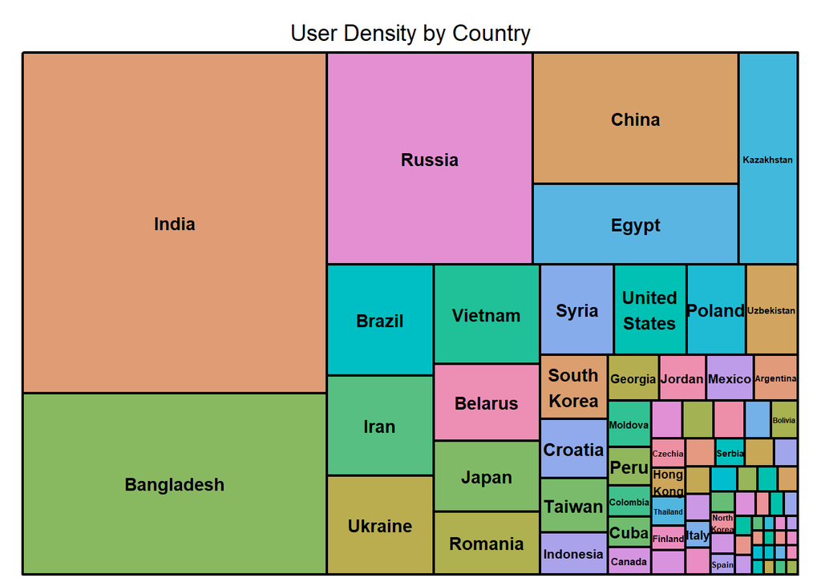

There are 79 unique countries within `userData`, along with an additional factor level for the programmers who do not have a recorded country.

What is the experience of the programmers in `userData`?

|  | level | count |
| --- | --- | --- |
| 2 | beginner | 1509 |
| 4 | intermediate | 1410 |
| 1 | advanced | 570 |
| 3 | expert | 82 |

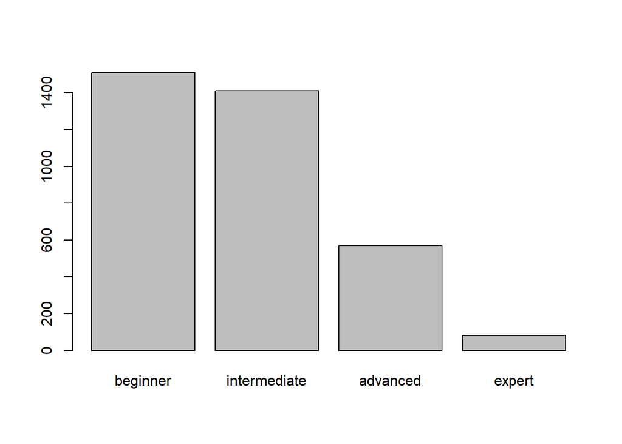

The bulk of our programmers lie within the beginner and intermediate levels.

# **Data Preparation**

Now that we have explored our data, it’s time to prepare them for model training and testing. To start things off, we will first join all three of the data tables into one big set. After joining the data, we will perfrom some feature engineering and then will split the data into training data and test data.

Let’s join our data sets:

```r
data <- join(historyData, userData, by = "user_id", type = "inner", match = "all")
data <- join(data, problemData, by = "problem_id", type = "inner", match = "all")
```

| user_id | problem_id | attempts_range | submission_count | problem_solved | contribution | country | follower_count | last_online_time_seconds | max_rating | rating | rank | registration_time_seconds | level_type | points | tags |
| --- | --- | --- | --- | --- | --- | --- | --- | --- | --- | --- | --- | --- | --- | --- | --- |
| user_232 | prob_6507 | 1 | 53 | 47 | 0 | Bangladesh | 1 | 1503633778 | 307.913 | 206.709 | beginner | 1432110935 | B | 1000 | strings |
| user_3568 | prob_2994 | 3 | 133 | 118 | 0 |  | 0 | 1502200122 | 324.255 | 235.378 | beginner | 1454664414 | C | 1500 | brute force,dp |
| user_1600 | prob_5071 | 1 | 50 | 44 | 0 |  | 7 | 1504719542 | 343.177 | 229.358 | beginner | 1473490873 | A | 500 | implementation |
| user_2256 | prob_703 | 1 | 271 | 233 | 23 | Indonesia | 40 | 1505175115 | 436.927 | 399.083 | intermediate | 1447736644 | A | 500 | brute force,implementation |
| user_2321 | prob_356 | 1 | 155 | 135 | 0 | India | 80 | 1505421849 | 492.546 | 472.190 | advanced | 1437724657 | D | 2000 | dfs and similar,trees |
| user_1569 | prob_6064 | 1 | 173 | 161 | 0 |  | 21 | 1504870431 | 462.729 | 462.729 | advanced | 1480812045 | C | 2000 | dp,string suffix structures,trees |
| user_3293 | prob_1237 | 1 | 855 | 811 | 0 | Egypt | 87 | 1505561409 | 398.222 | 368.979 | intermediate | 1439756111 | B | 1000 | implementation |
| user_915 | prob_4125 | 2 | 254 | 217 | 0 | Brazil | 21 | 1505581625 | 433.486 | 395.356 | intermediate | 1464182831 | B | 1000 | greedy,sortings |
| user_2032 | prob_1943 | 1 | 216 | 199 | 0 | India | 28 | 1505534677 | 387.328 | 387.328 | intermediate | 1443374825 | C | NA | greedy |
| user_1410 | prob_3935 | 1 | 390 | 350 | 0 | Bangladesh | 56 | 1505556770 | 315.367 | 217.890 | beginner | 1384505273 | C | 1000 | greedy,sortings |
| user_2085 | prob_5436 | 1 | 439 | 426 | 0 | China | 21 | 1505555602 | 524.656 | 505.447 | advanced | 1473818621 | C | 1500 | data structures |
| user_1810 | prob_3431 | 2 | 301 | 227 | 0 | Vietnam | 27 | 1504604213 | 467.030 | 337.156 | intermediate | 1413472596 | C | 1500 | brute force,constructive algorithms,implementation |
| user_1287 | prob_3474 | 1 | 294 | 268 | 0 | Romania | 35 | 1505035867 | 475.631 | 475.631 | advanced | 1394801704 | B | 1000 | constructive algorithms,implementation,sortings |
| user_2063 | prob_2872 | 1 | 652 | 595 | 20 | Czechia | 132 | 1505589460 | 655.677 | 577.695 | advanced | 1264978137 | A | 500 | implementation |
| user_724 | prob_6043 | 2 | 404 | 382 | 0 | Bangladesh | 351 | 1505564922 | 471.330 | 471.330 | advanced | 1401604903 | E | NA | combinatorics |
| user_88 | prob_1914 | 2 | 63 | 46 | 0 |  | 8 | 1485290430 | 315.654 | 286.411 | beginner | 1433181713 | C | 1500 | dsu,graphs,greedy |
| user_2269 | prob_5641 | 1 | 753 | 697 | 0 | Spain | 36 | 1505338257 | 497.420 | 479.644 | advanced | 1361908706 | I | NA | dp,flows,greedy |
| user_489 | prob_522 | 1 | 112 | 97 | 0 | India | 5 | 1505550351 | 320.528 | 295.298 | beginner | 1474378098 | A | 500 | implementation,math,number theory |
| user_1997 | prob_32 | 1 | 50 | 45 | 0 | Japan | 1 | 1494402344 | 440.654 | 440.654 | intermediate | 1479664011 | B | 500 | constructive algorithms,greedy |
| user_1929 | prob_5731 | 2 | 58 | 51 | 0 |  | 0 | 1505552744 | 330.275 | 262.901 | beginner | 1480086231 | A | NA | implementation,math,number theory |
| user_2084 | prob_4232 | 1 | 625 | 536 | 152 | Russia | 1054 | 1505583926 | 778.670 | 770.069 | expert | 1278517887 | G | 2500 | bitmasks,graphs,math,trees |
| user_923 | prob_3508 | 2 | 106 | 93 | 0 |  | 13 | 1505560570 | 413.704 | 394.209 | intermediate | 1466175804 | A | 500 | implementation |
| user_150 | prob_6488 | 1 | 273 | 218 | -2 | Bangladesh | 76 | 1504959860 | 313.647 | 258.888 | beginner | 1446995678 | D | 2000 | dp |
| user_2898 | prob_1605 | 1 | 728 | 691 | 13 | India | 135 | 1505475218 | 442.661 | 415.998 | intermediate | 1438803475 | C | NA | brute force,implementation |
| user_3086 | prob_2605 | 1 | 335 | 314 | 0 | India | 12 | 1501138300 | 391.628 | 391.628 | intermediate | 1419955527 | A | 500 | brute force,graphs,math |
| user_2552 | prob_534 | 1 | 273 | 247 | 0 | Russia | 31 | 1502089475 | 482.798 | 479.931 | advanced | 1425050679 | B | 1000 | implementation,strings |
| user_508 | prob_3073 | 1 | 488 | 412 | 6 | Ukraine | 58 | 1504107513 | 493.979 | 461.869 | advanced | 1328857430 | J | NA |  |
| user_1910 | prob_6442 | 4 | 240 | 218 | 0 | Bangladesh | 50 | 1505252563 | 319.954 | 291.284 | beginner | 1385471472 | B | NA |  |
| user_1066 | prob_106 | 1 | 286 | 264 | 11 | Romania | 50 | 1505404965 | 464.736 | 422.305 | intermediate | 1439111687 | C | 1500 | greedy,sortings |
| user_1637 | prob_1482 | 1 | 15 | 8 | 0 |  | 0 | 1490814904 | 307.913 | 260.894 | beginner | 1449672047 | B | 1000 | brute force,greedy |
| user_2561 | prob_164 | 2 | 75 | 62 | 0 |  | 8 | 1490229262 | 362.672 | 314.507 | intermediate | 1464880431 | A | 500 | brute force,constructive algorithms,math |
| user_812 | prob_5804 | 1 | 323 | 294 | 0 | Bangladesh | 29 | 1505564372 | 327.122 | 305.333 | beginner | 1451234328 | A | 500 | implementation |
| user_2340 | prob_6426 | 2 | 928 | 890 | 0 | Egypt | 45 | 1505127874 | 449.255 | 449.255 | intermediate | 1414378522 | D | 2000 | binary search,data structures,two pointers |
| user_1912 | prob_1149 | 3 | 227 | 220 | 0 | South Korea | 73 | 1501164956 | 474.197 | 456.135 | advanced | 1442512820 | D | 1750 | binary search,constructive algorithms,greedy |
| user_3185 | prob_1346 | 1 | 171 | 116 | 2 | Kazakhstan | 50 | 1495985840 | 383.028 | 347.190 | intermediate | 1360078434 | G | NA |  |
| user_1102 | prob_1047 | 1 | 135 | 119 | 0 | China | 13 | 1504976582 | 383.601 | 371.560 | intermediate | 1459917649 | C | NA | brute force |
| user_1150 | prob_3038 | 1 | 91 | 73 | 0 |  | 7 | 1505073613 | 379.874 | 359.232 | intermediate | 1477245233 | A | 500 | implementation |
| user_771 | prob_5954 | 3 | 329 | 319 | 0 | Iran | 8 | 1490966884 | 338.303 | 300.459 | beginner | 1477936158 | A | 500 | implementation,number theory |
| user_1155 | prob_6321 | 1 | 205 | 176 | 0 | Japan | 10 | 1505579156 | 502.867 | 502.867 | advanced | 1474523245 | A | NA | implementation,math |
| user_3221 | prob_1084 | 2 | 115 | 89 | 0 |  | 5 | 1504283943 | 322.534 | 286.411 | beginner | 1455097213 | D | 2000 | dfs and similar,dp |
| user_2307 | prob_2811 | 1 | 89 | 75 | 0 | Croatia | 10 | 1504291602 | 355.791 | 346.044 | intermediate | 1481912449 | A | NA |  |
| user_2906 | prob_620 | 4 | 111 | 95 | 0 | Moldova | 18 | 1505391376 | 307.626 | 289.851 | beginner | 1475164257 | A | 500 | dfs and similar,graphs,implementation |
| user_1828 | prob_4076 | 1 | 370 | 338 | 1 | Kazakhstan | 21 | 1504794362 | 336.296 | 336.296 | intermediate | 1460556896 | B | 1000 | binary search,dp,greedy,two pointers |
| user_194 | prob_6266 | 1 | 509 | 441 | 0 | India | 67 | 1505317093 | 465.596 | 441.514 | intermediate | 1450273924 | A | 500 | math |
| user_3155 | prob_1095 | 1 | 93 | 75 | 0 |  | 0 | 1504533023 | 305.619 | 180.906 | beginner | 1475683699 | A | NA | greedy,shortest paths |
| user_3568 | prob_4278 | 1 | 133 | 118 | 0 |  | 0 | 1502200122 | 324.255 | 235.378 | beginner | 1454664414 | A | 500 | implementation,math |
| user_2953 | prob_4407 | 1 | 438 | 367 | 0 | Colombia | 51 | 1504925966 | 407.683 | 385.321 | intermediate | 1352243962 | B | 750 | brute force,implementation |
| user_807 | prob_4053 | 2 | 1530 | 1524 | 13 | Egypt | 129 | 1505583116 | 473.624 | 473.624 | advanced | 1435534067 | D | 2000 | dfs and similar,dp,trees |
| user_661 | prob_583 | 1 | 900 | 843 | 0 | Vietnam | 97 | 1505581566 | 594.323 | 594.323 | advanced | 1380889769 | B | 1000 | geometry,math |
| user_1964 | prob_1481 | 1 | 329 | 270 | -9 | Bangladesh | 29 | 1505582889 | 356.651 | 340.596 | intermediate | 1417410074 | B | 1000 | brute force,implementation |

*NOTE: This table only includes the first 50 observations.

## Feature Engineering

There are additional features that can be extracted from the data.

```
## Classes 'data.table' and 'data.frame':   155295 obs. of  8 variables:
##  $ bin_points      : Factor w/ 12 levels "0","1","2","3",..: 6 7 4 4 8 8 6 6 1 6 ...
##  $ weeks_registered: num  118.3 78.6 51.6 95 111.9 ...
##  $ activity        : num  2.516 0.666 1.174 0.408 0.829 ...
##  $ avg_attempts    : num  1.87 2.27 1.67 1.61 1.53 ...
##  $ min_attempts    : num  1 1 1 1 1 1 1 1 1 1 ...
##  $ max_attempts    : num  6 5 4 5 5 4 6 4 4 6 ...
##  $ avg_submissions : num  1.13 1.13 1.14 1.16 1.15 ...
##  $ region          : Factor w/ 9 levels "Africa","Asia",..: 2 8 8 2 2 8 1 6 2 2 ...
##  - attr(*, ".internal.selfref")=<externalptr>
```

| bin_points | weeks_registered | activity | avg_attempts | min_attempts | max_attempts | avg_submissions | region |
| --- | --- | --- | --- | --- | --- | --- | --- |
| 5 | 118.25867 | 2.5161419 | 1.870968 | 1 | 6 | 1.127660 | Asia |
| 6 | 78.59740 | 0.6660797 | 2.272727 | 1 | 5 | 1.127119 | Unknown |
| 3 | 51.63470 | 1.1735160 | 1.666667 | 1 | 4 | 1.136364 | Unknown |
| 3 | 94.97102 | 0.4076009 | 1.607143 | 1 | 5 | 1.163090 | Asia |
| 7 | 111.93319 | 0.8291347 | 1.529412 | 1 | 5 | 1.148148 | Asia |
| 7 | 39.77908 | 0.2470750 | 1.455696 | 1 | 4 | 1.074534 | Unknown |
| 5 | 108.80506 | 0.1341616 | 1.754098 | 1 | 6 | 1.054254 | Africa |
| 5 | 68.45039 | 0.3154396 | 1.508772 | 1 | 4 | 1.170507 | South America |
| 0 | 102.77753 | 0.5164700 | 1.383562 | 1 | 4 | 1.085427 | Asia |
| 5 | 200.15128 | 0.5718608 | 2.057692 | 1 | 6 | 1.114286 | Asia |
| 6 | 52.47517 | 0.1231811 | 1.959184 | 1 | 6 | 1.030516 | Asia |
| 6 | 150.68058 | 0.6637911 | 1.508197 | 1 | 5 | 1.325991 | Asia |
| 5 | 182.26548 | 0.6800951 | 1.480519 | 1 | 5 | 1.097015 | Middle East |
| 3 | 397.83618 | 0.6686322 | 1.500000 | 1 | 6 | 1.095798 | East Europe |
| 0 | 171.89157 | 0.4499779 | 1.614286 | 1 | 6 | 1.057592 | Asia |
| 6 | 86.15859 | 1.8730129 | 1.882353 | 1 | 5 | 1.369565 | Unknown |
| 0 | 237.15204 | 0.3402468 | 1.711111 | 1 | 6 | 1.080344 | West Europe |
| 3 | 51.54142 | 0.5313549 | 1.729167 | 1 | 5 | 1.154639 | Asia |
| 3 | 24.36894 | 0.5415319 | 1.580645 | 1 | 4 | 1.111111 | Asia |
| 0 | 42.10733 | 0.8256339 | 1.853659 | 1 | 6 | 1.137255 | Unknown |
| 8 | 375.43988 | 0.7004475 | 1.328767 | 1 | 6 | 1.166045 | East Europe |
| 3 | 65.12031 | 0.7002184 | 1.688525 | 1 | 6 | 1.139785 | Unknown |
| 7 | 95.84025 | 0.4396342 | 2.394737 | 1 | 6 | 1.252294 | Asia |
| 0 | 110.23767 | 0.1595335 | 1.436620 | 1 | 3 | 1.053546 | Asia |
| 3 | 134.23078 | 0.4274865 | 2.108696 | 1 | 6 | 1.066879 | Asia |
| 5 | 127.37896 | 0.5157043 | 1.877551 | 1 | 6 | 1.105263 | East Europe |
| 0 | 289.76535 | 0.7033140 | 1.466667 | 1 | 3 | 1.184466 | East Europe |
| 0 | 198.05075 | 0.9084897 | 1.639344 | 1 | 5 | 1.100917 | Asia |
| 6 | 109.61190 | 0.4151966 | 1.705882 | 1 | 4 | 1.083333 | Middle East |
| 5 | 68.02721 | 8.5034013 | 2.000000 | 1 | 6 | 1.875000 | Unknown |
| 3 | 41.91275 | 0.6760121 | 2.075000 | 1 | 6 | 1.209677 | Unknown |
| 3 | 89.83142 | 0.3055491 | 1.754386 | 1 | 4 | 1.098639 | Asia |
| 7 | 150.04853 | 0.1685939 | 2.620000 | 1 | 6 | 1.042697 | Africa |
| 7 | 96.97774 | 0.4408079 | 1.716981 | 1 | 5 | 1.031818 | Asia |
| 0 | 224.71463 | 1.9371951 | 1.783784 | 1 | 5 | 1.474138 | Asia |
| 0 | 74.50220 | 0.6260689 | 1.895833 | 1 | 6 | 1.134454 | Asia |
| 3 | 46.01253 | 0.6303087 | 1.710526 | 1 | 6 | 1.246575 | Unknown |
| 3 | 21.54551 | 0.0675408 | 1.728571 | 1 | 4 | 1.031348 | Middle East |
| 0 | 51.34906 | 0.2917560 | 1.563636 | 1 | 4 | 1.164773 | Asia |
| 7 | 81.32727 | 0.9137895 | 2.047619 | 1 | 6 | 1.292135 | Unknown |
| 0 | 37.00257 | 0.4933676 | 1.384615 | 1 | 6 | 1.186667 | East Europe |
| 3 | 49.97870 | 0.5260916 | 1.849057 | 1 | 6 | 1.168421 | East Europe |
| 5 | 73.14396 | 0.2164022 | 1.660000 | 1 | 6 | 1.094675 | Asia |
| 3 | 91.01053 | 0.2063731 | 1.711539 | 1 | 6 | 1.154195 | Asia |
| 0 | 47.70060 | 0.6360080 | 1.703704 | 1 | 5 | 1.240000 | Unknown |
| 3 | 78.59740 | 0.6660797 | 2.272727 | 1 | 5 | 1.127119 | Unknown |
| 4 | 252.45040 | 0.6878758 | 1.758621 | 1 | 6 | 1.193461 | South America |
| 7 | 115.82184 | 0.0759986 | 1.554217 | 1 | 5 | 1.003937 | Africa |
| 5 | 206.17030 | 0.2445674 | 1.370786 | 1 | 6 | 1.067616 | Asia |
| 5 | 145.78838 | 0.5399570 | 1.451613 | 1 | 5 | 1.218519 | Asia |

**The above table shows additional features that have been engineered and added to the data. Below is a list of explanations for each new variable:**

- `bin_points`: Due to how dirty the data in the `points` feature is, I initially thought that I would drop the column entirely. Some problems don’t offer any points at all, while others offer negative points (For example, we can see that prob_5031 offers -1 points). Dirty data is often worse than no data. Nevertheless, my feelings changed once I realized that there might be some value in the fact that the `points` feature can help distinguish between problems within the same level. For example, one problem within level “A” might offer 500 points, while another problem of the same level might offer 250 points. Perhaps there’s a story here that we don’t see? Perhaps the `points` feature is similar to bonus points, signifying something special about a particular problem? After realizing this, I decided that I would bin the `points` feature into particular ranges. For example, 0== NA, 1== `points`<=100, 2== `points` >100 & <=250, etc.
- `weeks_registered`: The product of `registration_time_seconds` subtracted from `last_online_time_seconds` and then divided by the total seconds in a week. This is to find out how long a user has been on the platform.
- `activity`: The product of `weeks_registered`divided by `problem_solved`. This will hopefully serve as a proxy for how active each user is on the platform.
- `avg_attempts`/`min_attempts`/`max_attempts`: Features based on the `attempts_range` for each programmer.
- `avg_submissions`: The product of `submission_count` divided by `problems_solved`. This is a similar variable to `avg_attempts`, but is perhaps more precise since the `attempts_range` consists of binned values, while `submission_count` is the total submissions of a user.
- `region`: A tranformed factor variable of the `country` feature where observations have been assigned into respective regions: East Europe, West Europe, USA, South America, Middle East, Africa, Asia, Other, and Unknown. I anticipate that this will help with prospective sparsity issues for when we split up the data – We have a few countries where there are only 1-3 users.

**The following is a list of additional feature manipulation:**

- `attempts_range` was converted into a factor variable.
- The unknown `level_type` was renamed as level “X”. The variable was also classified as a factor.
- `rank` was converted into a factor variable.

**Features to be engineered from `problemData`:**

- I will create features based on the different `tags` of each problem. The best way to accomplish this is to simply breakout each individual tag into their own dummy variables. By doing this, we can observe heterogeneous characteristics between problems.

```r
#sparse matrix

#create a list or vector, comma delimited

#find unique for the new tag list
#create columns out of the unique tags
# populate column  %in% _> TFTFFTFTT
```

- I could make four additional variables for the mean attempts that a given problem is solved for beginner, intermediate, advanced, and expert

## Split Data

As with most data science projects, we need to split our data into training data and test data. The training data will be used throughout the rest of this project for model development, while the test data won’t be used for anything other than the final tests of our trained models.

Before we split our data, let’s drop the features that we no longer need, namely `user_id`, `problem_id`, `country`, `last_online_time_seconds`, `registrations_time_seconds`, `points`, and `tags` (For now) . We will join test predictions to their respective `user_id` and `problem_id` later on.

```r
data <- subset(data, select= -c(user_id, problem_id, country,
                last_online_time_seconds, registration_time_seconds, points, tags))
```

In order to avoid any systematic bias, we will split up the data at random:

```r
data$attempts_range <- as.numeric(data$attempts_range)
randIndex <- sample(1:dim(data)[1])
cutPoint2_3 <- floor(2*dim(data)[1]/3)
train <- data[randIndex[1:cutPoint2_3],]
test <- data[randIndex[(cutPoint2_3+1):dim(data)[1]],]
test.y<- test[,"attempts_range"]
test <- test[,c(-1)]
```

# **Model Selection & Training**

With our models, we will be making predictions between the `attempts_range` values of 1-6 for each observation. This is a regression problem and we will want to explore a variety of methods to tackle this. The methods that we will explore are Linear Regression, Random Forest, and Neural Network. With each model we will minimize the RSS and then round predictions to the closest digit (i.e., 1.7 -> 2, 4.1 -> 4, etc.).

## Linear Regression

For our baseline model, we are going to perform the Linear Regression model. To perform this function, we require very little effort.

```r
lsModel <- train(attempts_range ~ .,
                 train,
                 method = "lm",
                 trControl = trainControl(
                   method = "cv", number = 5,
                   verboseIter = TRUE
                 ))
```

```
## Linear Regression
##
## 103530 samples
##     16 predictor
##
## No pre-processing
## Resampling: Cross-Validated (5 fold)
## Summary of sample sizes: 82825, 82825, 82824, 82823, 82823
## Resampling results:
##
##   RMSE      Rsquared   MAE
##   1.014135  0.1115449  0.7423248
##
## Tuning parameter 'intercept' was held constant at a value of TRUE
```

**Pros of Linear Regression**

- Very easy to impliment
- Computationally fast and inexpensive
- High interpretability

**Cons of Linear Regression**

- Potentially weaker than other, more advanced methods

## Feature Selection

There is more that we can do to better tune this model and subsequent models: Feature Selection. The test error of a model will decrease and then begin to increase at some point as a model becomes more complex (e.g., Increase in the number of features). Because of this, we need to minimize the complexity of our model while optimizing its error rate. We do this by selecting the absolute best features we can.

An initial step for feature selection is to remove highly correlated features from our models.

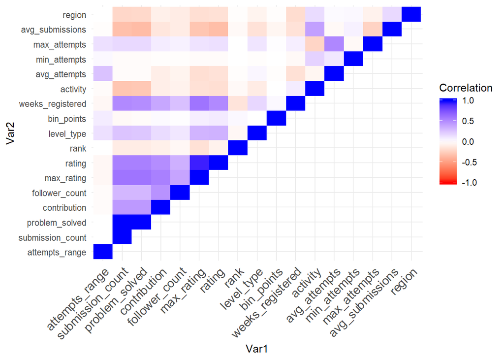

From the above image, along with some additional calculations, we can determine that the following features in our data have a high correlation and would need to be removed from our models.

```
## [1] "submission_count" "max_rating"       "rating"
## [4] "max_attempts"
```

We can choose to eliminate the above variables from our models. However, there are other methods for feature selection that might be more useful. Another method is to run a model to rank the importance of each feature:

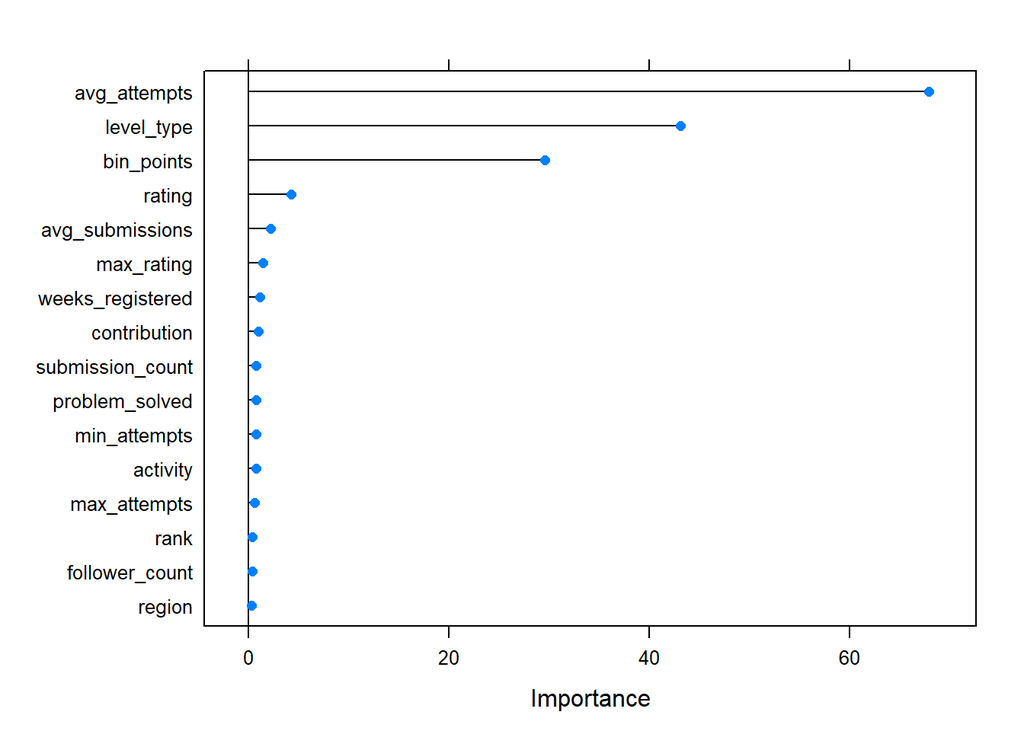

It’s rather phenominal to see that `bin_points` is one of our most important variables. You might remember that I was originally planning on eliminating the `points` variable from which `bin_points` was derived.

Lastly, we can use Recursive Feature Elimination to find the optimal combination of features that produces the best error score while minimizing the complexity of our model.

```r
control <- rfeControl(functions=rfFuncs, method="cv", number=5)
results <- rfe(train[1:1000,2:16], as.matrix(train[1:1000,1]), sizes = c(1:16), rfeControl=control)
```

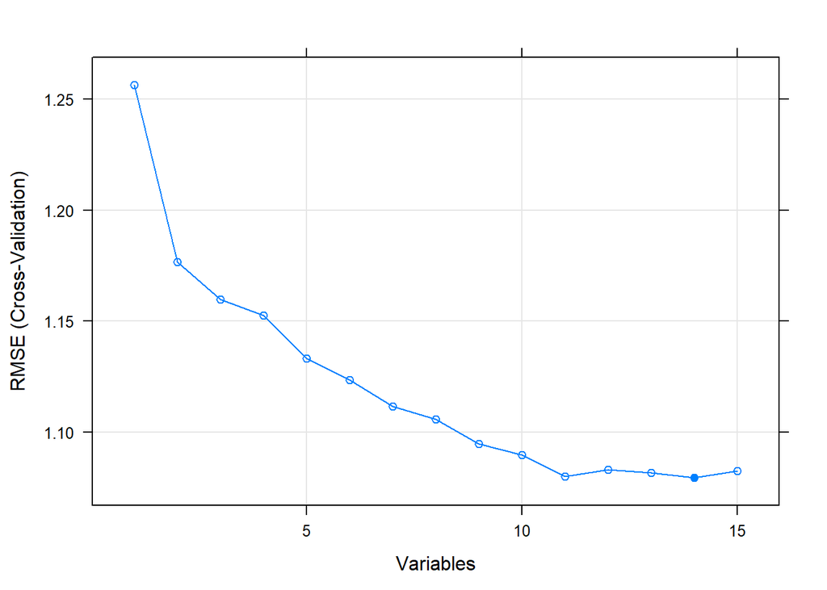

The following list is the optimal combination of our features:

```r
predictors(results)
```

```
##  [1] "avg_attempts"     "max_rating"       "problem_solved"
##  [4] "follower_count"   "rating"           "submission_count"
##  [7] "level_type"       "bin_points"       "activity"
## [10] "weeks_registered" "max_attempts"     "rank"
## [13] "contribution"     "avg_submissions"
```

```r
lsModel2 <- train(attempts_range ~ avg_attempts + bin_points + problem_solved + activity,
                 train,
                 method = "lm",
                 trControl = trainControl(
                   method = "cv", number = 5,
                   verboseIter = TRUE
                 ))

lsModel2
```

[output not shown]

## Random Forest

With Random Forest, we will need to find the optimal tuning parameters, just like with our Linear Regression model.

```r
rfModel <- train(attempts_range ~ avg_attempts + bin_points + problem_solved + activity,
                 train[1:5000],
                 method = "rf",
                 trControl = trainControl(
                   method = "cv", number = 5,
                   verboseIter = TRUE
                 ))
rfModel
```

[output not shown]

```r
rfModel <- randomForest(attempts_range ~ avg_attempts + bin_points + problem_solved + activity,
                    data = train[1:50000,], mtry = 2, ntree = 100, importance = TRUE)

rfModel
```

[output not shown]

**Pros of Random Forest**

- Very dynamic and applicable in a number of settings
- Usually very accurate without a lot of tuning

**Cons of Random Forest**

- Low interpretability
- Computationally expensive

## Neural Network

Our final model and hopefully our best option out of the three methods will be the Neural Network.

```r
library(e1071)
library(RSNNS)

targetlabel <- decodeClassLabels(train[,1])
trainSet <- splitForTrainingAndTest(train[,2:ncol(train)],
                                    targetlabel)

train <- normTrainingAndTestSet(train, type= "0_1")

nn1 <- mlp(x = trainSet$inputsTrain, y = trainSet$targetsTrain,
           size = c(10, 10, 10), maxit = 8, inputsTest = trainSet$inputsTest,
           targetsTest = trainSet$targetsTest)
```

**Pros of Neural Network**

- Very dynamic and applicable in a variety of settings
- Usually very accurate

**Cons of Neural Network**

- Low interpretability
- Computationally expensive

# Final Testing

## Linear Regression

```r
ls.test.predictions <- predict(lsModel2,newdata=test)
```

## Random Forest

```r
rf.test.predictions <- predict(rfModel,newdata=test)
```

## Neural Network

```r
test.nnPred <- predict(nn1, newdata = testData)

nn.out <- as.data.frame(test.nnPred)

x <- max.col(nn.out)

x <- data.frame(x)

x <- x - 1
```

# Conclusion

Thank you for reading! Please let me know if you have any questions or comments. You can reach me directly either via email at jacob.w.lyman@gmail.com or via [my Linkedin page](https://www.linkedin.com/in/jacobwlyman/).